# Multifactorial multi-plate qPCR analysis

Edward Wallace

June 2018

# Plan

This vignette shows how to use tidyqpcr functions to normalize and plot data from multifactorial experiments: many primer sets, many conditions, two plates.

This is real RT-qPCR data by Edward Wallace in June 2018, testing the effect of heat shock and transcription-targeting drugs in *Saccharomyces cerevisiae* yeast.

## Pilot experiment

Do standard transcriptional inhibitors phenanthroline and thiolutin block the transcriptional heat shock response in yeast? This is a genuine question because some papers that argue that phenanthroline and thiolutin **induce** the transcriptional heat shock response.

Measure 16 primer sets: HOR7, HSP12, HSP26, HSP78, HSP104, RTC3, SSA4, PGK1, ALG9, HHT2, HTB2, RPS3, RPS13, RPS15, RPS30A, RPL39.

Test 6 conditions. That’s 3 transcriptional inhibitors (no drug control, 150ug/mL 1,10-phenanthroline, 3ug/mL thiolutin) in each of 2 conditions (- heat shock control, + heat shock 42C 10min), 2 biol reps each:

```
- C- Control -HS
- P- phenanthroline -HS
- T- thiolutin -HS
- C+ Control +HS
- P+ phenanthroline +HS
- T+ thiolutin +HS
```

## Label and plan plates

Reverse transcription by random primers (mixed with oligo-dT??)

```r
# list Targets /Probes
Probes <- c("HOR7", "HSP12", "HSP26", "HSP78",
            "HSP104", "RTC3", "SSA4", "PGK1",
            "ALG9", " HHT2", "HTB2", "RPS3",
            "RPS13", "RPS15", "RPS30A", "RPL39")

rowkey <- tibble(WellR=LETTERS[1:16],
                 Probe=factor(Probes,levels=Probes)
                 )

# Set up experimental samples
HSlevels <- c("-","+")
HSvalues <- factor(rep(HSlevels,each=3),levels=HSlevels)
Druglevels <- c("C","P","T")
Drugvalues <- factor(rep(Druglevels,times=2),levels=Druglevels)
Conditionlevels <- paste0(Druglevels,rep(HSlevels,each=3))
Conditionvalues <- factor(Conditionlevels,levels=Conditionlevels)

colkey <- create_colkey_6in24(HS=HSvalues,
                              Drug=Drugvalues,
                              Condition=Conditionvalues)

plateplan <-
    label_plate_rowcol(create_blank_plate(WellR = LETTERS[1:16],WellC=1:24),
                       rowkey,colkey)
```

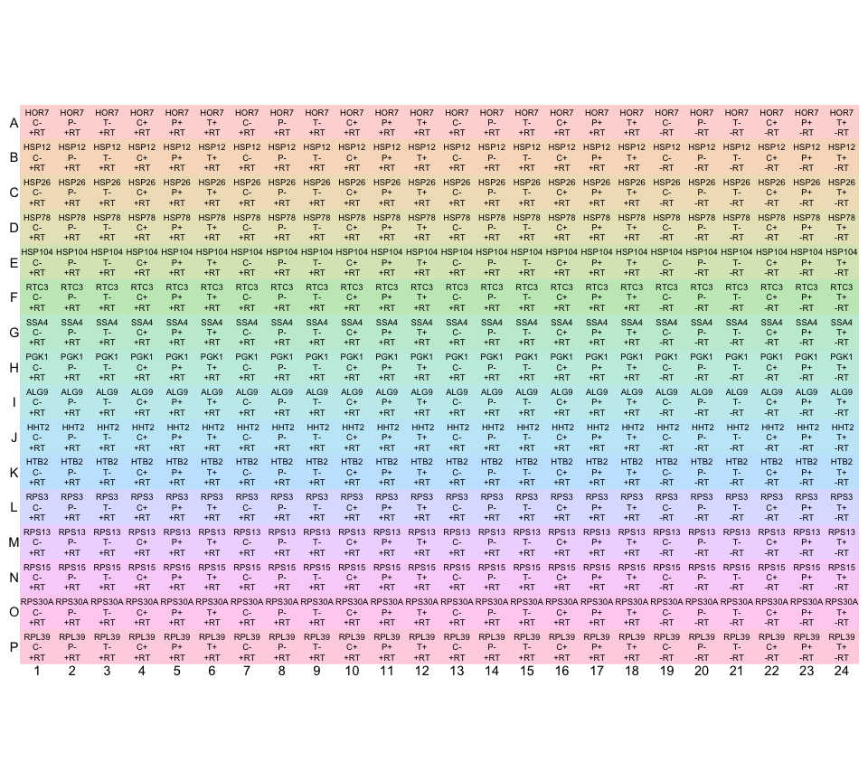

```r
display_plate( plateplan %>%
    mutate(Sample=Condition) )
```

## Load and summarize data

```r
# set working directory, if needed
# setwd("~/Dropbox (Drummond Lab)/EdinburghLab/RT-qPCR/2018-06/")
# read my plates

plate1 <- read_tsv("../inst/extdata/Edward_qPCR_TxnInhibitors_HS_2018-06-15_plate1_Ct.txt",skip=1) %>%
    mutate(Well=Pos,Ct=Cp) %>%
    left_join(plateplan) %>%
    mutate(BiolRep="1",Plate="1")


plate2 <- read_tsv("../inst/extdata/Edward_qPCR_TxnInhibitors_HS_2018-06-15_plate2_Ct.txt",skip=1) %>%
    mutate(Well=Pos,Ct=Cp) %>%
    left_join(plateplan) %>%
    mutate(BiolRep="2",Plate="2")

plates <- bind_rows(plate1,plate2) %>%
    mutate( Sample=paste0(Condition,BiolRep) )

summary(plates)
```

```
##  Include            Color           Pos                Name
##  Mode:logical   Min.   :  255   Length:768         Length:768
##  TRUE:768       1st Qu.:  255   Class :character   Class :character
##                 Median :  255   Mode  :character   Mode  :character
##                 Mean   : 9738
##                 3rd Qu.:  255
##                 Max.   :65280
##
##        Cp        Concentration     Standard  Status
##  Min.   : 3.11   Mode:logical   Min.   :0   Mode:logical
##  1st Qu.:15.92   NA's:768       1st Qu.:0   NA's:768
##  Median :18.12                  Median :0
##  Mean   :19.86                  Mean   :0
##  3rd Qu.:21.19                  3rd Qu.:0
##  Max.   :37.51                  Max.   :0
##  NA's   :112
##      Well                 Ct            WellR         WellC
##  Length:768         Min.   : 3.11   A      : 48   Min.   : 1.00
##  Class :character   1st Qu.:15.92   B      : 48   1st Qu.: 6.75
##  Mode  :character   Median :18.12   C      : 48   Median :12.50
##                     Mean   :19.86   D      : 48   Mean   :12.50
##                     3rd Qu.:21.19   E      : 48   3rd Qu.:18.25
##                     Max.   :37.51   F      : 48   Max.   :24.00
##                     NA's   :112     (Other):480
##   Type     TechRep HS      Drug    Condition     Probe
##  +RT:576   1:384   -:384   C:256   C-:128    HOR7   : 48
##  -RT:192   2:192   +:384   P:256   P-:128    HSP12  : 48
##            3:192           T:256   T-:128    HSP26  : 48
##                                    C+:128    HSP78  : 48
##                                    P+:128    HSP104 : 48
##                                    T+:128    RTC3   : 48
##                                              (Other):480
##    BiolRep             Plate              Sample
##  Length:768         Length:768         Length:768
##  Class :character   Class :character   Class :character
##  Mode  :character   Mode  :character   Mode  :character
##
##
##
##
```

# Plot unnormalized data

## -RT controls are low

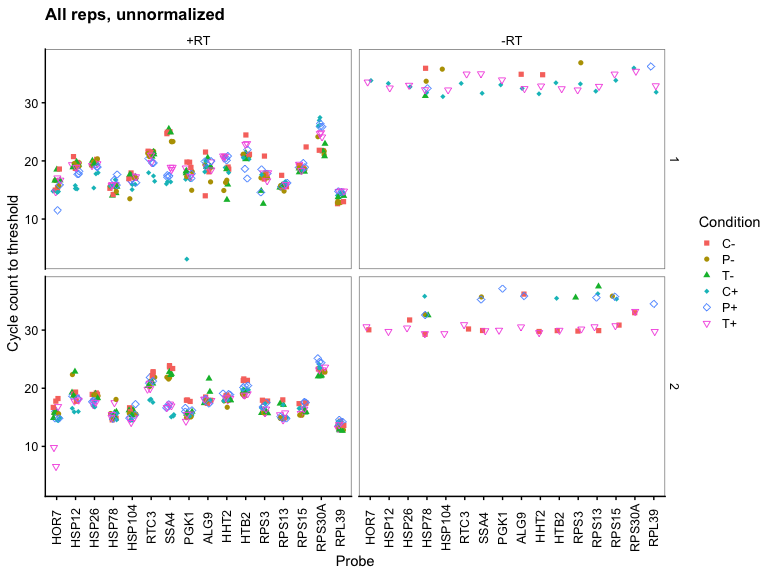

```r
ggplot(data=plates) +
    geom_point(aes(x=Probe,y=Ct,shape=Condition,colour=Condition),
               position=position_jitter(width = 0.2,height=0)) +
    labs(y="Cycle count to threshold",
         title="All reps, unnormalized") +
    scale_shape_manual(values=c(15:18,5:6)) +
    facet_grid(BiolRep~Type) +
    theme(axis.text.x=element_text(angle=90,vjust=0.5),
          panel.border=element_rect(fill = NA,linetype=1,
                                    colour = "grey50",size=0.5))
```

## Normalize Ct to PGK1, within Sample only

```r
platesnorm <- plates %>%
    filter(Type=="+RT") %>%
    normalizeqPCR(normProbes = "PGK1")

platesmed <- platesnorm %>%
    group_by(Sample,Condition,BiolRep,HS,Drug,Sample,Probe) %>%
    summarize(Ct=median(Value.norm,na.rm=TRUE),
              Abund=median(Value.normexp,na.rm=TRUE))

filter(platesmed,Probe=="HSP26")
```

[output not shown]

## Plot normalized data, all reps

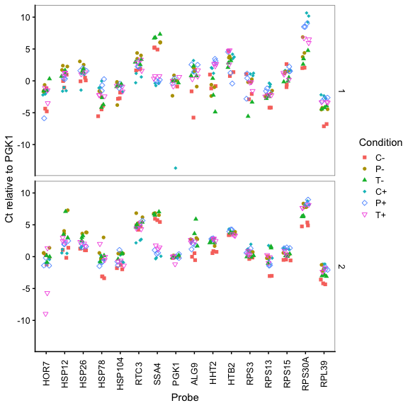

```r
ggplot(data=platesnorm) +
    geom_point(aes(x=Probe,y=Value.norm,shape=Condition,colour=Condition),
               position=position_jitter(width = 0.2,height=0)) +
    labs(y="Ct relative to PGK1") +
    scale_shape_manual(values=c(15:18,5:6)) +
    facet_grid(BiolRep~.) +
    theme(axis.text.x=element_text(angle=90,vjust=0.5),
          panel.border=element_rect(fill = NA,linetype=1,
                                    colour = "grey50",size=0.5))
```

## Plot normalized data, summarized vs Probe

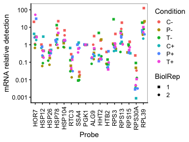

```r
ggplot(data=platesmed) +
    geom_point(aes(x=Probe,y=Abund,shape=BiolRep,colour=Condition),
               position=position_jitter(width = 0.2,height=0)) +
    scale_shape_manual(values=c(15:18,5:6)) +
    scale_y_log10nice("mRNA relative detection") +
    theme(axis.text.x=element_text(angle=90,vjust=0.5),
          panel.border=element_rect(fill = NA,linetype=1,
                                    colour = "grey50",size=0.5))
```

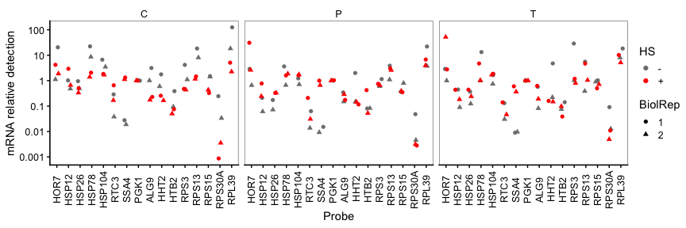

```r
ggplot(data=platesmed) +
    geom_point(aes(x=Probe,y=Abund,shape=BiolRep,colour=HS),
               position=position_jitter(width = 0.2,height=0)) +
    facet_wrap(~Drug,ncol=3) +
    scale_colour_manual(values=c("-"="grey50","+"="red")) +
    scale_y_log10nice("mRNA relative detection") +
    theme(axis.text.x=element_text(angle=90,vjust=0.5),
          panel.border=element_rect(fill = NA,linetype=1,
                                    colour = "grey50",size=0.5))
```

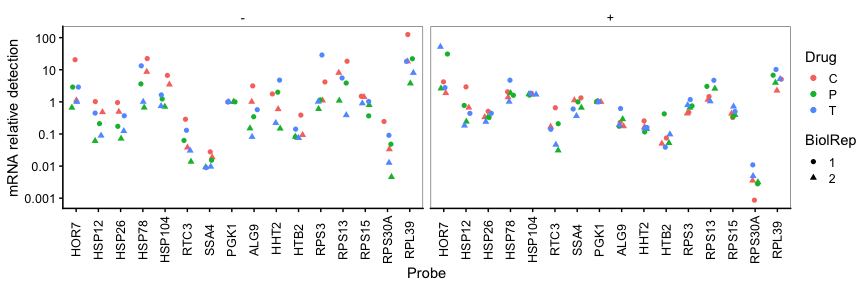

```r
ggplot(data=platesmed) +
    geom_point(aes(x=Probe,y=Abund,shape=BiolRep,colour=Drug),
               position=position_jitter(width = 0.2,height=0)) +
    facet_wrap(~HS,ncol=3) +
    scale_y_log10nice("mRNA relative detection") +
    theme(axis.text.x=element_text(angle=90,vjust=0.5),
          panel.border=element_rect(fill = NA,linetype=1,
                                    colour = "grey50",size=0.5))
```

# Melt and Amp Curves

```r
plate1curve <- read_tsv("../inst/extdata/Edward_qPCR_TxnInhibitors_HS_2018-06-15_plate1.txt",
                       skip=2,
                        col_names=c("Well","SID","Program","Segment",
                                    "Cycle","Time","Temperature","Fluor")
                      ) %>%
    debaseline() %>%
    left_join(plateplan) %>%
    mutate(BiolRep=1,Plate=1)

plate2curve <- read_tsv("../inst/extdata/Edward_qPCR_TxnInhibitors_HS_2018-06-15_plate2.txt",
                       skip=2,
                        col_names=c("Well","SID","Program","Segment",
                                    "Cycle","Time","Temperature","Fluor")
                      ) %>%
    debaseline() %>%
    left_join(plateplan)  %>%
    mutate(BiolRep=2,Plate=2)

# platesamp  <- plate1curve %>% filter(Program == 2)

# plate1curve
# plate2curve

platesamp <- bind_rows(plate1curve,plate2curve) %>%
    filter(Program == 2)

platesmelt <- bind_rows(plate1curve,plate2curve) %>%
    filter(Program != 2) %>%
    demelt() %>%
    filter(Temperature >= 61)
```

## Melt Curves, BiolRep 1

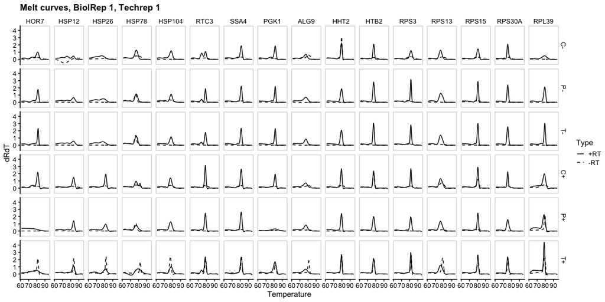

```r
ggplot(data=platesmelt %>%
           filter(TechRep==1,BiolRep==1),
       aes(x=Temperature,y=dRdT,linetype=Type)) +
    facet_grid(Condition~Probe) +
    geom_line() +
    scale_linetype_manual(values=c("-RT"="dashed","+RT"="solid")) +
    scale_x_continuous(breaks=seq(60,100,10),minor_breaks=seq(60,100,5)) +
    labs(title="Melt curves, BiolRep 1, Techrep 1") + panel_border()
```

## Melt Curves, BiolRep 2

[figure not shown]

```r
ggplot(data=platesmelt %>%
           filter(TechRep==1,BiolRep==2),
       aes(x=Temperature,y=dRdT,linetype=Type)) +
    facet_grid(Condition~Probe) +
    geom_line() +
    scale_linetype_manual(values=c("-RT"="dashed","+RT"="solid")) +
    scale_x_continuous(breaks=seq(60,100,10),minor_breaks=seq(60,100,5)) +
    labs(title="Melt curves, BiolRep 2, TechRep 1") + panel_border()
```

## Amp Curves, BiolRep 1

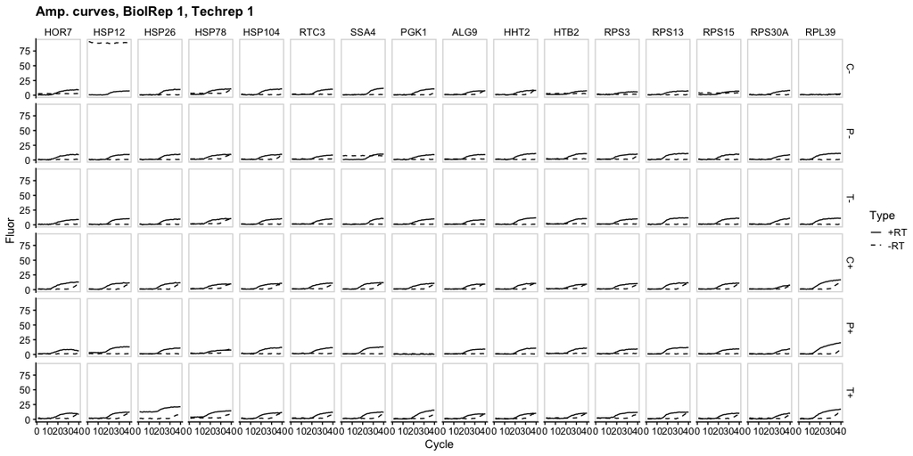

```r
ggplot(data=platesamp %>%
           filter(TechRep==1,BiolRep==1),
       aes(x=Cycle,y=Fluor,linetype=Type)) +
    facet_grid(Condition~Probe) +
    geom_line() +
    scale_linetype_manual(values=c("-RT"="dashed","+RT"="solid")) +
    expand_limits(y=0) +
    labs(title="Amp. curves, BiolRep 1, Techrep 1") + panel_border()
```

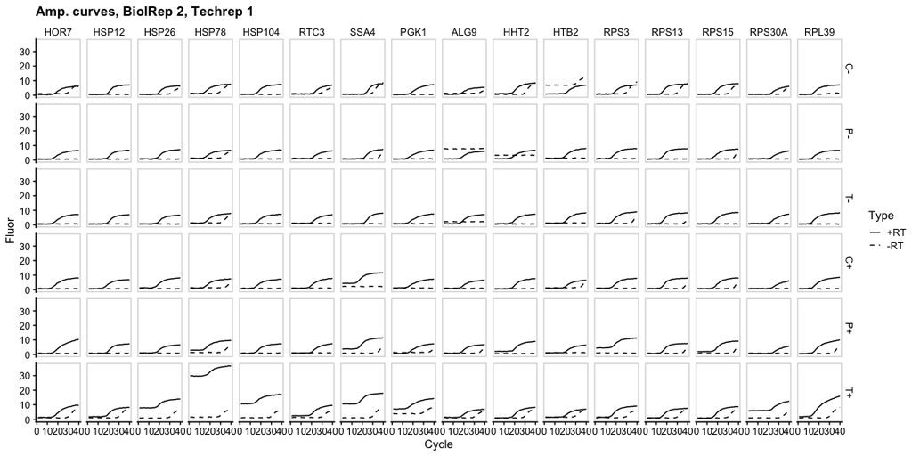

```r
ggplot(data=platesamp %>%
           filter(TechRep==1,BiolRep==2),
       aes(x=Cycle,y=Fluor,linetype=Type)) +
    facet_grid(Condition~Probe) +
    geom_line() +
    scale_linetype_manual(values=c("-RT"="dashed","+RT"="solid")) +
    expand_limits(y=0) +
    labs(title="Amp. curves, BiolRep 2, Techrep 1") + panel_border()
```